# Risk Factor Analysis

## Outcome Variable

**Outcome Variable:** ever_swasted

## Predictor Variables

**Intervention Variable:** gagebrth

**Adjustment Set:**

- arm
- sex
- W_mage
- meducyrs
- feducyrs
- hhwealth_quart
- W_nrooms
- W_nchldlt5
- brthmon
- W_parity
- impfloor
- impsan
- delta_W_mage
- delta_meducyrs
- delta_feducyrs
- delta_hhwealth_quart
- delta_W_nrooms
- delta_W_nchldlt5
- delta_brthmon
- delta_W_parity
- delta_impfloor
- delta_impsan

## Stratifying Variables

The analysis was stratified on these variable(s):

- agecat
- studyid
- country

## Data Summary

| agecat | studyid | country | gagebrth | ever_swasted | n_cell | n |
| --- | --- | --- | --- | --- | --- | --- |
| 0-24 months (no birth wast) | CMC-V-BCS-2002 | INDIA | Full or late term | 0 | 183 | 348 |
| 0-24 months (no birth wast) | CMC-V-BCS-2002 | INDIA | Full or late term | 1 | 30 | 348 |
| 0-24 months (no birth wast) | CMC-V-BCS-2002 | INDIA | Preterm | 0 | 42 | 348 |
| 0-24 months (no birth wast) | CMC-V-BCS-2002 | INDIA | Preterm | 1 | 10 | 348 |
| 0-24 months (no birth wast) | CMC-V-BCS-2002 | INDIA | Early term | 0 | 71 | 348 |
| 0-24 months (no birth wast) | CMC-V-BCS-2002 | INDIA | Early term | 1 | 12 | 348 |
| 0-24 months (no birth wast) | COHORTS | GUATEMALA | Full or late term | 0 | 441 | 809 |
| 0-24 months (no birth wast) | COHORTS | GUATEMALA | Full or late term | 1 | 7 | 809 |
| 0-24 months (no birth wast) | COHORTS | GUATEMALA | Preterm | 0 | 126 | 809 |
| 0-24 months (no birth wast) | COHORTS | GUATEMALA | Preterm | 1 | 4 | 809 |
| 0-24 months (no birth wast) | COHORTS | GUATEMALA | Early term | 0 | 222 | 809 |
| 0-24 months (no birth wast) | COHORTS | GUATEMALA | Early term | 1 | 9 | 809 |
| 0-24 months (no birth wast) | COHORTS | INDIA | Full or late term | 0 | 556 | 1345 |
| 0-24 months (no birth wast) | COHORTS | INDIA | Full or late term | 1 | 23 | 1345 |
| 0-24 months (no birth wast) | COHORTS | INDIA | Preterm | 0 | 294 | 1345 |
| 0-24 months (no birth wast) | COHORTS | INDIA | Preterm | 1 | 14 | 1345 |
| 0-24 months (no birth wast) | COHORTS | INDIA | Early term | 0 | 433 | 1345 |
| 0-24 months (no birth wast) | COHORTS | INDIA | Early term | 1 | 25 | 1345 |
| 0-24 months (no birth wast) | COHORTS | PHILIPPINES | Full or late term | 0 | 1073 | 2993 |
| 0-24 months (no birth wast) | COHORTS | PHILIPPINES | Full or late term | 1 | 85 | 2993 |
| 0-24 months (no birth wast) | COHORTS | PHILIPPINES | Preterm | 0 | 581 | 2993 |
| 0-24 months (no birth wast) | COHORTS | PHILIPPINES | Preterm | 1 | 52 | 2993 |
| 0-24 months (no birth wast) | COHORTS | PHILIPPINES | Early term | 0 | 1093 | 2993 |
| 0-24 months (no birth wast) | COHORTS | PHILIPPINES | Early term | 1 | 109 | 2993 |
| 0-24 months (no birth wast) | IRC | INDIA | Full or late term | 0 | 206 | 389 |
| 0-24 months (no birth wast) | IRC | INDIA | Full or late term | 1 | 43 | 389 |
| 0-24 months (no birth wast) | IRC | INDIA | Preterm | 0 | 34 | 389 |
| 0-24 months (no birth wast) | IRC | INDIA | Preterm | 1 | 8 | 389 |
| 0-24 months (no birth wast) | IRC | INDIA | Early term | 0 | 74 | 389 |
| 0-24 months (no birth wast) | IRC | INDIA | Early term | 1 | 24 | 389 |
| 0-24 months (no birth wast) | JiVitA-3 | BANGLADESH | Full or late term | 0 | 12677 | 25266 |
| 0-24 months (no birth wast) | JiVitA-3 | BANGLADESH | Full or late term | 1 | 457 | 25266 |
| 0-24 months (no birth wast) | JiVitA-3 | BANGLADESH | Preterm | 0 | 4924 | 25266 |
| 0-24 months (no birth wast) | JiVitA-3 | BANGLADESH | Preterm | 1 | 188 | 25266 |
| 0-24 months (no birth wast) | JiVitA-3 | BANGLADESH | Early term | 0 | 6763 | 25266 |
| 0-24 months (no birth wast) | JiVitA-3 | BANGLADESH | Early term | 1 | 257 | 25266 |
| 0-24 months (no birth wast) | Keneba | GAMBIA | Full or late term | 0 | 711 | 1692 |
| 0-24 months (no birth wast) | Keneba | GAMBIA | Full or late term | 1 | 127 | 1692 |
| 0-24 months (no birth wast) | Keneba | GAMBIA | Preterm | 0 | 218 | 1692 |
| 0-24 months (no birth wast) | Keneba | GAMBIA | Preterm | 1 | 38 | 1692 |
| 0-24 months (no birth wast) | Keneba | GAMBIA | Early term | 0 | 530 | 1692 |
| 0-24 months (no birth wast) | Keneba | GAMBIA | Early term | 1 | 68 | 1692 |
| 0-24 months (no birth wast) | NIH-Crypto | BANGLADESH | Full or late term | 0 | 165 | 754 |
| 0-24 months (no birth wast) | NIH-Crypto | BANGLADESH | Full or late term | 1 | 3 | 754 |
| 0-24 months (no birth wast) | NIH-Crypto | BANGLADESH | Preterm | 0 | 250 | 754 |
| 0-24 months (no birth wast) | NIH-Crypto | BANGLADESH | Preterm | 1 | 11 | 754 |
| 0-24 months (no birth wast) | NIH-Crypto | BANGLADESH | Early term | 0 | 319 | 754 |
| 0-24 months (no birth wast) | NIH-Crypto | BANGLADESH | Early term | 1 | 6 | 754 |
| 0-24 months (no birth wast) | PROBIT | BELARUS | Full or late term | 0 | 8516 | 16879 |
| 0-24 months (no birth wast) | PROBIT | BELARUS | Full or late term | 1 | 105 | 16879 |
| 0-24 months (no birth wast) | PROBIT | BELARUS | Preterm | 0 | 583 | 16879 |
| 0-24 months (no birth wast) | PROBIT | BELARUS | Preterm | 1 | 8 | 16879 |
| 0-24 months (no birth wast) | PROBIT | BELARUS | Early term | 0 | 7576 | 16879 |
| 0-24 months (no birth wast) | PROBIT | BELARUS | Early term | 1 | 91 | 16879 |
| 0-24 months (no birth wast) | TanzaniaChild2 | TANZANIA, UNITED REPUBLIC OF | Full or late term | 0 | 1325 | 2242 |
| 0-24 months (no birth wast) | TanzaniaChild2 | TANZANIA, UNITED REPUBLIC OF | Full or late term | 1 | 60 | 2242 |
| 0-24 months (no birth wast) | TanzaniaChild2 | TANZANIA, UNITED REPUBLIC OF | Preterm | 0 | 323 | 2242 |
| 0-24 months (no birth wast) | TanzaniaChild2 | TANZANIA, UNITED REPUBLIC OF | Preterm | 1 | 21 | 2242 |
| 0-24 months (no birth wast) | TanzaniaChild2 | TANZANIA, UNITED REPUBLIC OF | Early term | 0 | 483 | 2242 |
| 0-24 months (no birth wast) | TanzaniaChild2 | TANZANIA, UNITED REPUBLIC OF | Early term | 1 | 30 | 2242 |

The following strata were considered:

- agecat: 0-24 months (no birth wast), studyid: CMC-V-BCS-2002, country: INDIA
- agecat: 0-24 months (no birth wast), studyid: COHORTS, country: GUATEMALA
- agecat: 0-24 months (no birth wast), studyid: COHORTS, country: INDIA
- agecat: 0-24 months (no birth wast), studyid: COHORTS, country: PHILIPPINES
- agecat: 0-24 months (no birth wast), studyid: IRC, country: INDIA
- agecat: 0-24 months (no birth wast), studyid: JiVitA-3, country: BANGLADESH
- agecat: 0-24 months (no birth wast), studyid: Keneba, country: GAMBIA
- agecat: 0-24 months (no birth wast), studyid: NIH-Crypto, country: BANGLADESH
- agecat: 0-24 months (no birth wast), studyid: PROBIT, country: BELARUS
- agecat: 0-24 months (no birth wast), studyid: TanzaniaChild2, country: TANZANIA, UNITED REPUBLIC OF

### Dropped Strata

Some strata were dropped due to rare outcomes:

- agecat: 0-24 months (no birth wast), studyid: COHORTS, country: GUATEMALA
- agecat: 0-24 months (no birth wast), studyid: NIH-Crypto, country: BANGLADESH

## Methods Detail

We're interested in the causal parameters $E[Y_a]$ for all values of $a \in \mathcal{A}$. These parameters represent the mean outcome if, possibly contrary to fact, we intervened to set all units to have $A=a$. Under the randomization and positivity assumptions, these are identified by the statistical parameters $\psi_a=E_W[E_{Y|A,W}(Y|A=a,W)]$. In addition, we're interested in the mean of $Y$, $E[Y]$ under no intervention (the observed mean). We will estimate these parameters by using SuperLearner to fit the relevant likelihood factors -- $E_{Y|A,W}(Y|A=a,W)$ and $p(A=a|W)$, and then updating our likelihood fit using a joint TMLE.

For unadjusted analyses ($W=\{\}$), initial likelihoods were estimated using Lrnr_glm to estimate the simple $E(Y|A)$ and Lrnr_mean to estimate $p(A)$. For adjusted analyses, a small library containing Lrnr_glmnet, Lrnr_xgboost, and Lrnr_mean was used.

Having estimated these parameters, we will then use the delta method to estimate relative risks and attributable risks relative to a prespecified baseline level of $A$.

# Results Detail

## Results Plots

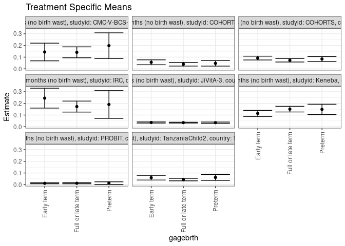

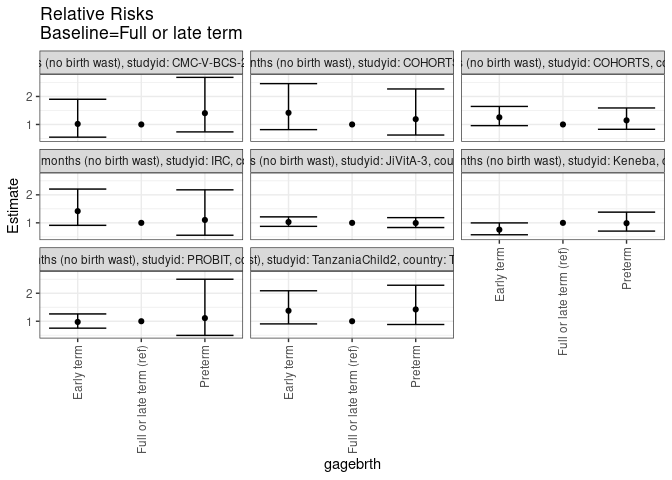

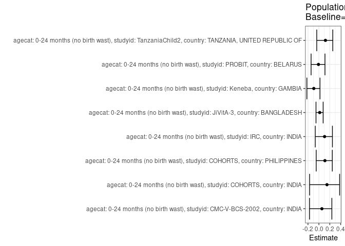

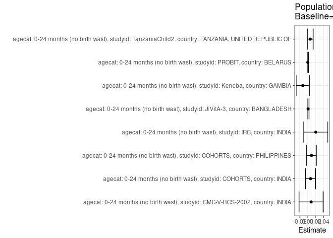

## Results Table

### Parameter: TSM

| agecat | studyid | country | intervention_level | baseline_level | estimate | ci_lower | ci_upper |
| --- | --- | --- | --- | --- | --- | --- | --- |
| 0-24 months (no birth wast) | CMC-V-BCS-2002 | INDIA | Full or late term | NA | 0.1412047 | 0.0943186 | 0.1880909 |
| 0-24 months (no birth wast) | CMC-V-BCS-2002 | INDIA | Preterm | NA | 0.1982342 | 0.0881977 | 0.3082708 |
| 0-24 months (no birth wast) | CMC-V-BCS-2002 | INDIA | Early term | NA | 0.1439046 | 0.0682609 | 0.2195483 |
| 0-24 months (no birth wast) | COHORTS | INDIA | Full or late term | NA | 0.0392592 | 0.0235095 | 0.0550088 |
| 0-24 months (no birth wast) | COHORTS | INDIA | Preterm | NA | 0.0466733 | 0.0230592 | 0.0702873 |
| 0-24 months (no birth wast) | COHORTS | INDIA | Early term | NA | 0.0555986 | 0.0345858 | 0.0766113 |
| 0-24 months (no birth wast) | COHORTS | PHILIPPINES | Full or late term | NA | 0.0731173 | 0.0581530 | 0.0880816 |
| 0-24 months (no birth wast) | COHORTS | PHILIPPINES | Preterm | NA | 0.0838408 | 0.0625417 | 0.1051400 |
| 0-24 months (no birth wast) | COHORTS | PHILIPPINES | Early term | NA | 0.0917613 | 0.0755562 | 0.1079663 |
| 0-24 months (no birth wast) | IRC | INDIA | Full or late term | NA | 0.1726908 | 0.1256823 | 0.2196992 |
| 0-24 months (no birth wast) | IRC | INDIA | Preterm | NA | 0.1904762 | 0.0715664 | 0.3093860 |
| 0-24 months (no birth wast) | IRC | INDIA | Early term | NA | 0.2448980 | 0.1596489 | 0.3301470 |
| 0-24 months (no birth wast) | JiVitA-3 | BANGLADESH | Full or late term | NA | 0.0351755 | 0.0316745 | 0.0386765 |
| 0-24 months (no birth wast) | JiVitA-3 | BANGLADESH | Preterm | NA | 0.0349826 | 0.0296092 | 0.0403560 |
| 0-24 months (no birth wast) | JiVitA-3 | BANGLADESH | Early term | NA | 0.0362207 | 0.0313174 | 0.0411241 |
| 0-24 months (no birth wast) | Keneba | GAMBIA | Full or late term | NA | 0.1505908 | 0.1262902 | 0.1748915 |
| 0-24 months (no birth wast) | Keneba | GAMBIA | Preterm | NA | 0.1487338 | 0.1048416 | 0.1926260 |
| 0-24 months (no birth wast) | Keneba | GAMBIA | Early term | NA | 0.1140164 | 0.0885089 | 0.1395240 |
| 0-24 months (no birth wast) | PROBIT | BELARUS | Full or late term | NA | 0.0121796 | 0.0079391 | 0.0164200 |
| 0-24 months (no birth wast) | PROBIT | BELARUS | Preterm | NA | 0.0135364 | 0.0026530 | 0.0244198 |
| 0-24 months (no birth wast) | PROBIT | BELARUS | Early term | NA | 0.0118690 | 0.0079340 | 0.0158041 |
| 0-24 months (no birth wast) | TanzaniaChild2 | TANZANIA, UNITED REPUBLIC OF | Full or late term | NA | 0.0435620 | 0.0328368 | 0.0542872 |
| 0-24 months (no birth wast) | TanzaniaChild2 | TANZANIA, UNITED REPUBLIC OF | Preterm | NA | 0.0619075 | 0.0367235 | 0.0870915 |
| 0-24 months (no birth wast) | TanzaniaChild2 | TANZANIA, UNITED REPUBLIC OF | Early term | NA | 0.0598787 | 0.0396452 | 0.0801123 |

### Parameter: E(Y)

| agecat | studyid | country | intervention_level | baseline_level | estimate | ci_lower | ci_upper |
| --- | --- | --- | --- | --- | --- | --- | --- |
| 0-24 months (no birth wast) | CMC-V-BCS-2002 | INDIA | NA | NA | 0.1494253 | 0.1119149 | 0.1869357 |
| 0-24 months (no birth wast) | COHORTS | INDIA | NA | NA | 0.0460967 | 0.0348859 | 0.0573074 |
| 0-24 months (no birth wast) | COHORTS | PHILIPPINES | NA | NA | 0.0821918 | 0.0723504 | 0.0920332 |
| 0-24 months (no birth wast) | IRC | INDIA | NA | NA | 0.1928021 | 0.1535486 | 0.2320555 |
| 0-24 months (no birth wast) | JiVitA-3 | BANGLADESH | NA | NA | 0.0357002 | 0.0330794 | 0.0383209 |
| 0-24 months (no birth wast) | Keneba | GAMBIA | NA | NA | 0.1377069 | 0.1212828 | 0.1541310 |
| 0-24 months (no birth wast) | PROBIT | BELARUS | NA | NA | 0.0120860 | 0.0083142 | 0.0158578 |
| 0-24 months (no birth wast) | TanzaniaChild2 | TANZANIA, UNITED REPUBLIC OF | NA | NA | 0.0495094 | 0.0405280 | 0.0584908 |

### Parameter: RR

| agecat | studyid | country | intervention_level | baseline_level | estimate | ci_lower | ci_upper |
| --- | --- | --- | --- | --- | --- | --- | --- |
| 0-24 months (no birth wast) | CMC-V-BCS-2002 | INDIA | Full or late term | Full or late term | 1.0000000 | 1.0000000 | 1.0000000 |
| 0-24 months (no birth wast) | CMC-V-BCS-2002 | INDIA | Preterm | Full or late term | 1.4038779 | 0.7349898 | 2.6814975 |
| 0-24 months (no birth wast) | CMC-V-BCS-2002 | INDIA | Early term | Full or late term | 1.0191203 | 0.5466981 | 1.8997800 |
| 0-24 months (no birth wast) | COHORTS | INDIA | Full or late term | Full or late term | 1.0000000 | 1.0000000 | 1.0000000 |
| 0-24 months (no birth wast) | COHORTS | INDIA | Preterm | Full or late term | 1.1888500 | 0.6233827 | 2.2672500 |
| 0-24 months (no birth wast) | COHORTS | INDIA | Early term | Full or late term | 1.4161927 | 0.8161811 | 2.4572999 |
| 0-24 months (no birth wast) | COHORTS | PHILIPPINES | Full or late term | Full or late term | 1.0000000 | 1.0000000 | 1.0000000 |
| 0-24 months (no birth wast) | COHORTS | PHILIPPINES | Preterm | Full or late term | 1.1466618 | 0.8275308 | 1.5888632 |
| 0-24 months (no birth wast) | COHORTS | PHILIPPINES | Early term | Full or late term | 1.2549869 | 0.9579528 | 1.6441230 |
| 0-24 months (no birth wast) | IRC | INDIA | Full or late term | Full or late term | 1.0000000 | 1.0000000 | 1.0000000 |
| 0-24 months (no birth wast) | IRC | INDIA | Preterm | Full or late term | 1.1029900 | 0.5582108 | 2.1794403 |
| 0-24 months (no birth wast) | IRC | INDIA | Early term | Full or late term | 1.4181300 | 0.9115965 | 2.2061217 |
| 0-24 months (no birth wast) | JiVitA-3 | BANGLADESH | Full or late term | Full or late term | 1.0000000 | 1.0000000 | 1.0000000 |
| 0-24 months (no birth wast) | JiVitA-3 | BANGLADESH | Preterm | Full or late term | 0.9945156 | 0.8332141 | 1.1870434 |
| 0-24 months (no birth wast) | JiVitA-3 | BANGLADESH | Early term | Full or late term | 1.0297159 | 0.8738160 | 1.2134304 |
| 0-24 months (no birth wast) | Keneba | GAMBIA | Full or late term | Full or late term | 1.0000000 | 1.0000000 | 1.0000000 |
| 0-24 months (no birth wast) | Keneba | GAMBIA | Preterm | Full or late term | 0.9876681 | 0.7055192 | 1.3826530 |
| 0-24 months (no birth wast) | Keneba | GAMBIA | Early term | Full or late term | 0.7571273 | 0.5746832 | 0.9974916 |
| 0-24 months (no birth wast) | PROBIT | BELARUS | Full or late term | Full or late term | 1.0000000 | 1.0000000 | 1.0000000 |
| 0-24 months (no birth wast) | PROBIT | BELARUS | Preterm | Full or late term | 1.1114012 | 0.4942436 | 2.4991981 |
| 0-24 months (no birth wast) | PROBIT | BELARUS | Early term | Full or late term | 0.9745055 | 0.7534443 | 1.2604262 |
| 0-24 months (no birth wast) | TanzaniaChild2 | TANZANIA, UNITED REPUBLIC OF | Full or late term | Full or late term | 1.0000000 | 1.0000000 | 1.0000000 |
| 0-24 months (no birth wast) | TanzaniaChild2 | TANZANIA, UNITED REPUBLIC OF | Preterm | Full or late term | 1.4211356 | 0.8835053 | 2.2859245 |
| 0-24 months (no birth wast) | TanzaniaChild2 | TANZANIA, UNITED REPUBLIC OF | Early term | Full or late term | 1.3745642 | 0.9048568 | 2.0880949 |

### Parameter: PAR

| agecat | studyid | country | intervention_level | baseline_level | estimate | ci_lower | ci_upper |
| --- | --- | --- | --- | --- | --- | --- | --- |
| 0-24 months (no birth wast) | CMC-V-BCS-2002 | INDIA | Full or late term | NA | 0.0082205 | -0.0221909 | 0.0386320 |
| 0-24 months (no birth wast) | COHORTS | INDIA | Full or late term | NA | 0.0068375 | -0.0057310 | 0.0194060 |
| 0-24 months (no birth wast) | COHORTS | PHILIPPINES | Full or late term | NA | 0.0090745 | -0.0030344 | 0.0211834 |
| 0-24 months (no birth wast) | IRC | INDIA | Full or late term | NA | 0.0201113 | -0.0102472 | 0.0504698 |
| 0-24 months (no birth wast) | JiVitA-3 | BANGLADESH | Full or late term | NA | 0.0005247 | -0.0018151 | 0.0028645 |
| 0-24 months (no birth wast) | Keneba | GAMBIA | Full or late term | NA | -0.0128840 | -0.0294826 | 0.0037146 |
| 0-24 months (no birth wast) | PROBIT | BELARUS | Full or late term | NA | -0.0000935 | -0.0016320 | 0.0014449 |
| 0-24 months (no birth wast) | TanzaniaChild2 | TANZANIA, UNITED REPUBLIC OF | Full or late term | NA | 0.0059474 | -0.0013762 | 0.0132709 |

### Parameter: PAF

| agecat | studyid | country | intervention_level | baseline_level | estimate | ci_lower | ci_upper |
| --- | --- | --- | --- | --- | --- | --- | --- |
| 0-24 months (no birth wast) | CMC-V-BCS-2002 | INDIA | Full or late term | NA | 0.0550144 | -0.1716649 | 0.2378386 |
| 0-24 months (no birth wast) | COHORTS | INDIA | Full or late term | NA | 0.1483292 | -0.1700275 | 0.3800632 |
| 0-24 months (no birth wast) | COHORTS | PHILIPPINES | Full or late term | NA | 0.1104062 | -0.0492397 | 0.2457613 |
| 0-24 months (no birth wast) | IRC | INDIA | Full or late term | NA | 0.1043106 | -0.0668583 | 0.2480168 |
| 0-24 months (no birth wast) | JiVitA-3 | BANGLADESH | Full or late term | NA | 0.0146967 | -0.0530733 | 0.0781055 |
| 0-24 months (no birth wast) | Keneba | GAMBIA | Full or late term | NA | -0.0935610 | -0.2205325 | 0.0202018 |
| 0-24 months (no birth wast) | PROBIT | BELARUS | Full or late term | NA | -0.0077393 | -0.1431149 | 0.1116042 |
| 0-24 months (no birth wast) | TanzaniaChild2 | TANZANIA, UNITED REPUBLIC OF | Full or late term | NA | 0.1201264 | -0.0390715 | 0.2549333 |